# Stat 3301: Data Analysis Project Part 1

Krescens Kok

10/09/2019

# Sale Price

After analyzing the graphs, the distribution seems to have an approximately normal distribution, however it is skewed right. Since the mean is greater than the median, this also reveals that the data is skewed right because the data increases the value of the mean, but the median is resistant to outliers. Any data point above the price $358,512 is considered an outlier.

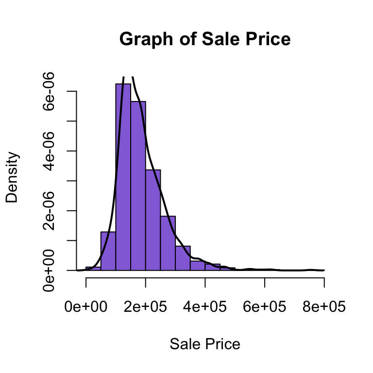

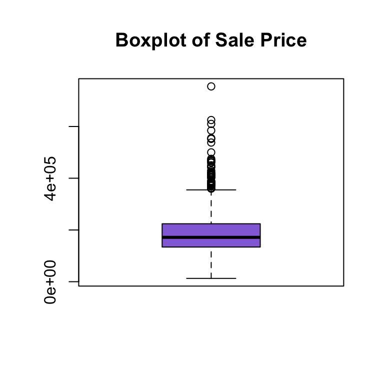

```
##    Min. 1st Qu.  Median    Mean 3rd Qu.    Max.
##   12789  134112  171500  185957  223875  755000
```

# Lot Area

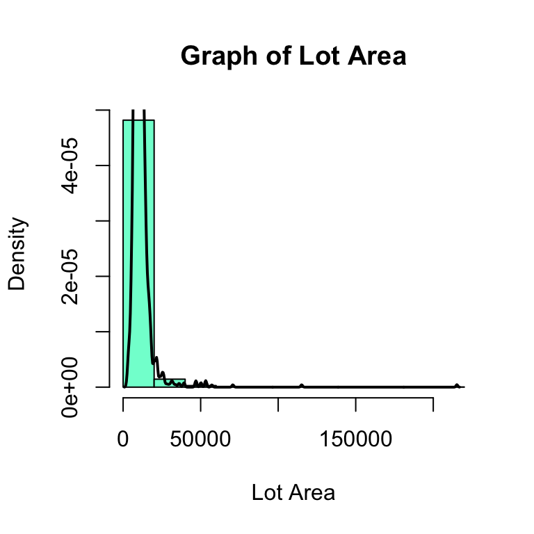

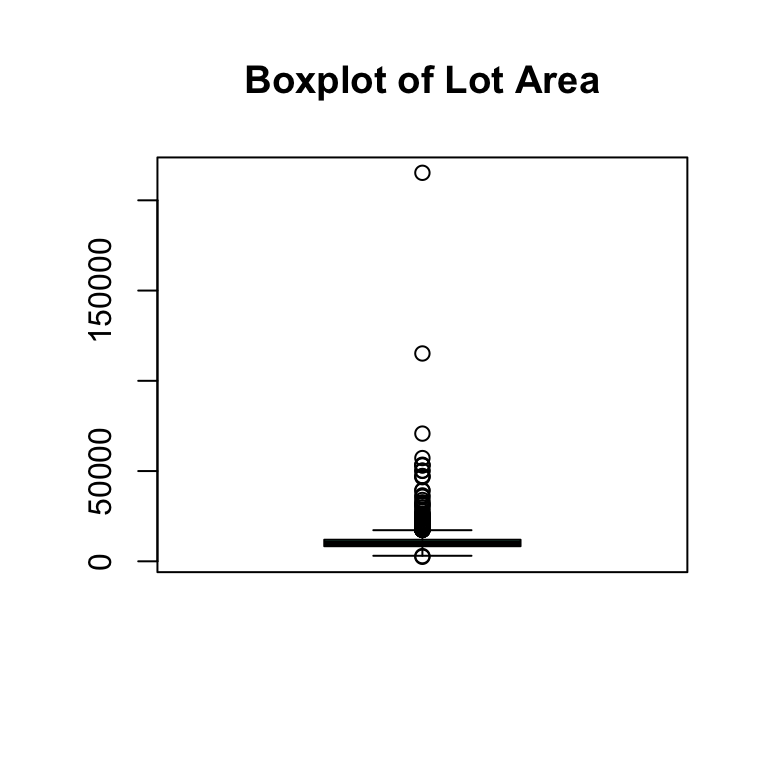

```
##    Min. 1st Qu.  Median    Mean 3rd Qu.    Max.
##    2500    8372    9876   11047   11956  215245
```

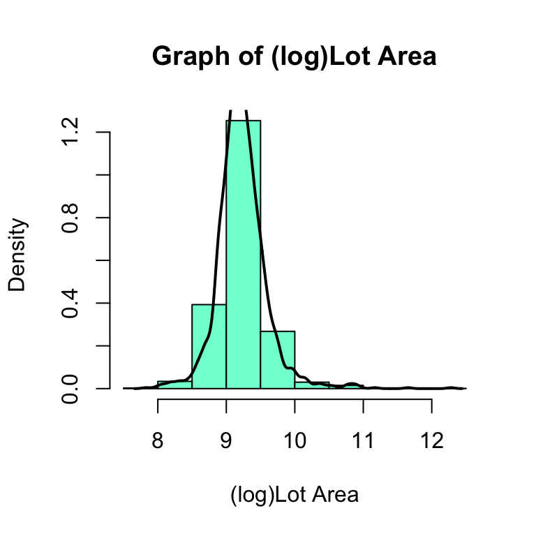

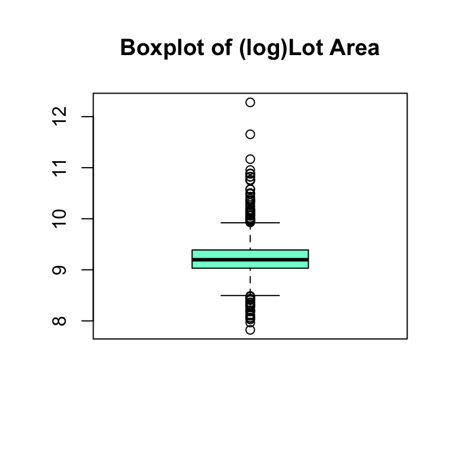

```
##    Min. 1st Qu.  Median    Mean 3rd Qu.    Max.
##   7.824   9.033   9.198   9.227   9.389  12.280
```

## Relating Sale Prices and Lot Areas

Using a scatterplot to graph the Sale Prices vs Lot Areas, it is hard to determine whether the variables are linearly correlated because the data points spread away from each other as the lot area increases. After using a log transformation on both variables, it doesn’t help because the same is seen as before.

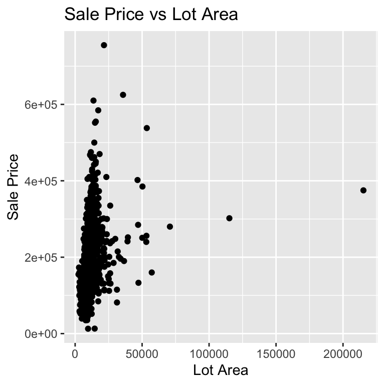

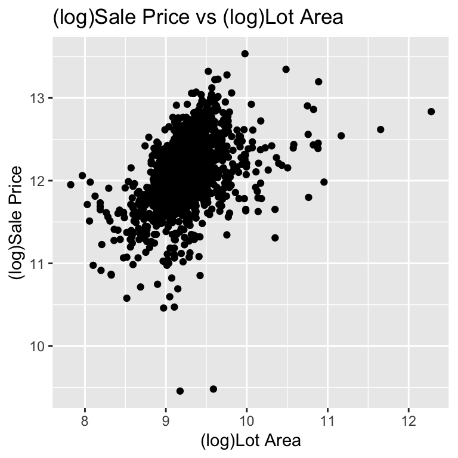

# Year Built

The data appears to have a multimodal distribution because there are multiple peaks and seems to be skewed left, however, the mean and median values are very close. Any data point below the year 1891 is considered an outlier.

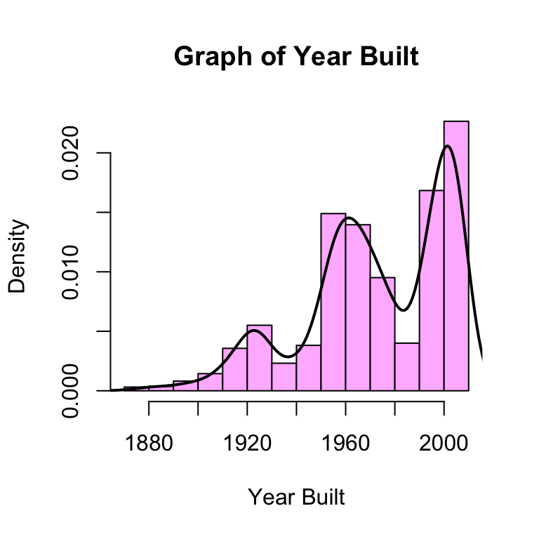

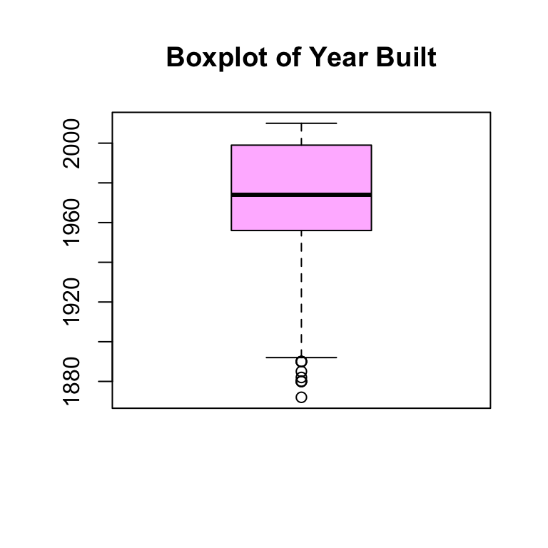

```
##    Min. 1st Qu.  Median    Mean 3rd Qu.    Max.
##    1872    1956    1974    1973    1999    2010
```

## Relating Sale Prices and Years

The scatterplot reveals a curvature pattern between the two variables, and even after doing a log transformation, it’s still hard to determine whether there is a linear regression, as there is still a curvature pattern to it.

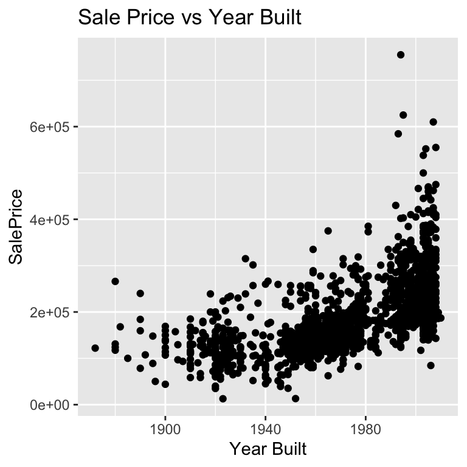

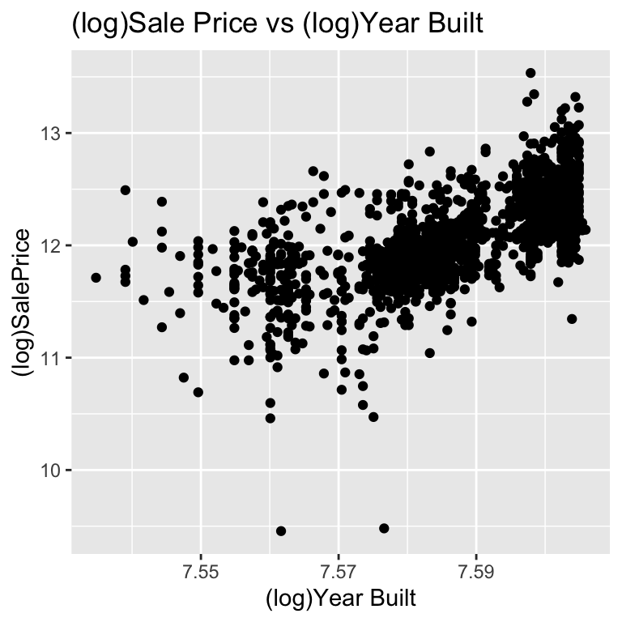

# Square Feet

The histogram of this graph is approximately normal, however there is a right skew present. The mean value is greater than the median which further explains the skew, and the data values increases the mean. Any data point above 2,849 square feet is considered an outlier. After performing a log transformation to the data points, the distribution becomes more normal and the median and mean values become closer in value.

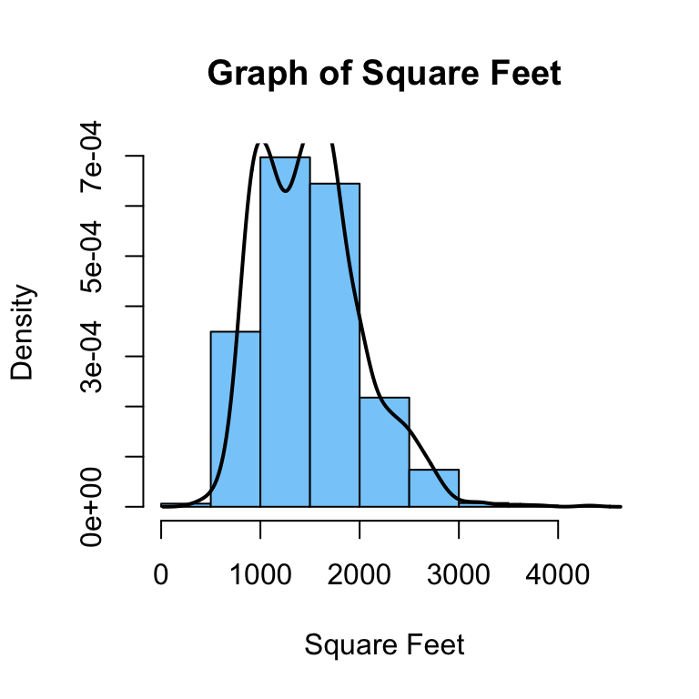

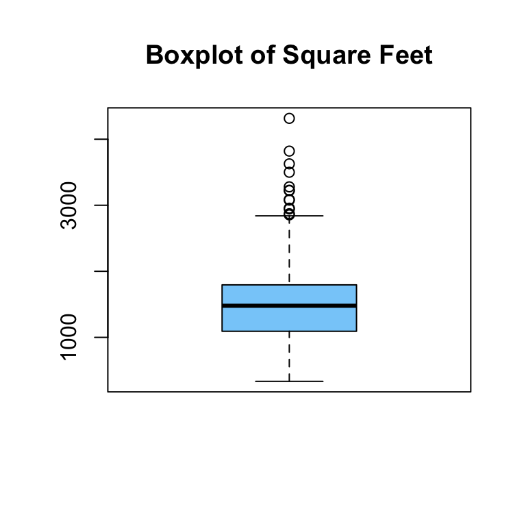

```
##    Min. 1st Qu.  Median    Mean 3rd Qu.    Max.
##     334    1092    1478    1505    1795    4316
```

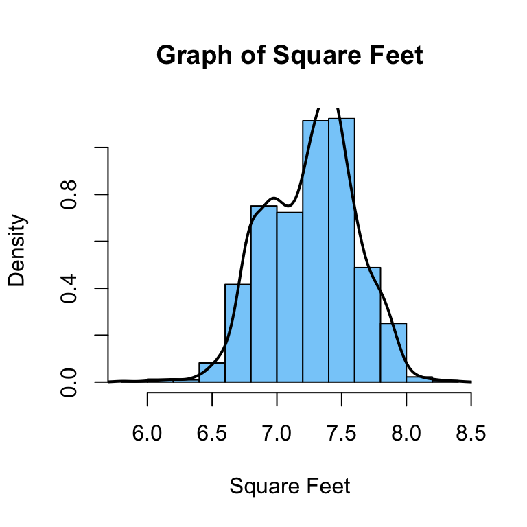

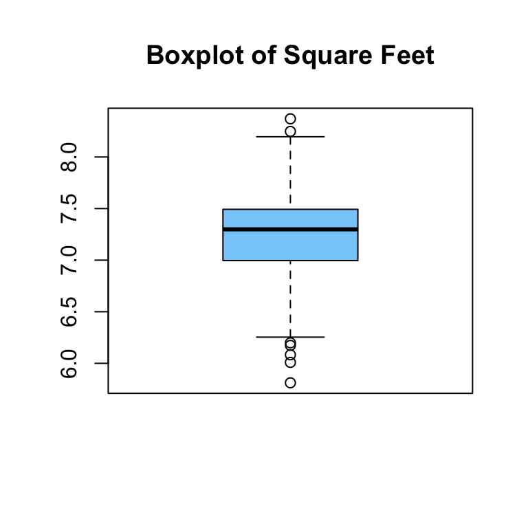

```
##    Min. 1st Qu.  Median    Mean 3rd Qu.    Max.
##   5.811   6.996   7.299   7.260   7.493   8.370
```

## Sale Prices vs Square Footage

As seen from the graph, it’s possible that the Sale Prices and Square Feet points have a linear regression, however, the data points still spread out as the Square Feet points increase. After doing a log transformation to both variables, it is much easier to conclude that a linear regression may fit the data appropriately. Looking at the residuals vs fitted values graph, for the Sale Price vs Square Feet, it is evident that the variance is not constant throughout. It continues to increase as the fitted values increase. However, looking at the log transformed Sale Price vs Square Feet graph, the variance is a litle better, however it still is not constant because it increases and then decreases as the x values increase.

Analyzing the p value of the null hypothesis test of the slope equalling zero, the p value is so small that the null hypothesis is rejected, and it is concluded that the slope is not zero. This is true for both linear regression models. In the first model, the $R^2$ value is 0.6399, which means that about 64% of the variance in the Sale Prices can be explained by the Square Feet values. In the second model, the $R^2$ value is 0.6594, which is slightly better than before, as about 66% of the variance in (log)Sale Prices can be explained by the (log) Square Feet values.

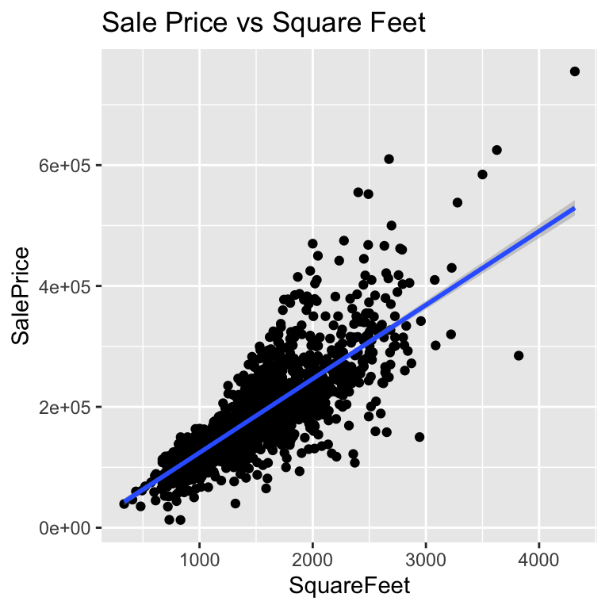

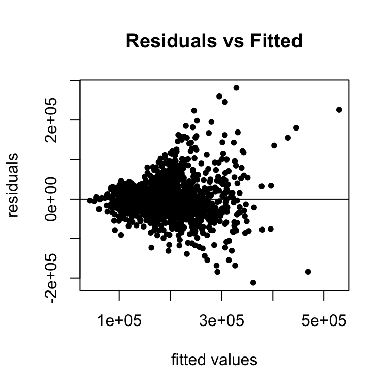

```
##
## Call:
## lm(formula = SalePrice ~ SqFt, data = houseData)
##
## Residuals:
##     Min      1Q  Median      3Q     Max
## -211699  -23895   -2042   18723  281284
##
## Coefficients:
##             Estimate Std. Error t value Pr(>|t|)
## (Intercept) 2066.430   3643.202   0.567    0.571
## SqFt         122.158      2.294  53.255   <2e-16 ***
## ---
## Signif. codes:  0 '***' 0.001 '**' 0.01 '*' 0.05 '.' 0.1 ' ' 1
##
## Residual standard error: 46440 on 1596 degrees of freedom
## Multiple R-squared:  0.6399, Adjusted R-squared:  0.6397
## F-statistic:  2836 on 1 and 1596 DF,  p-value: < 2.2e-16
```

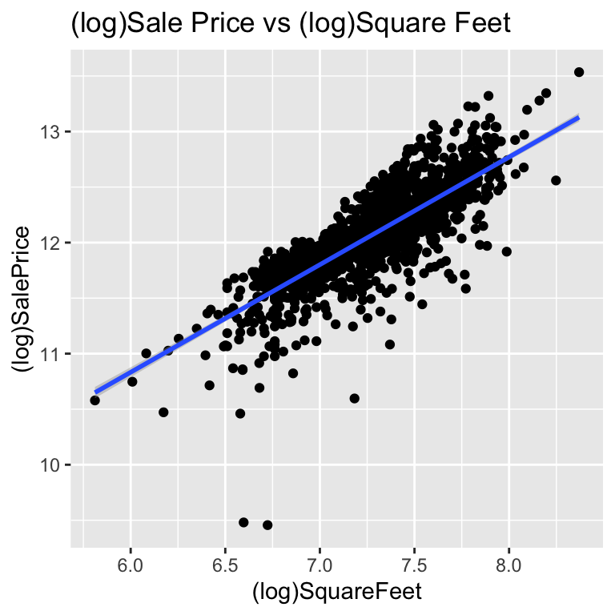

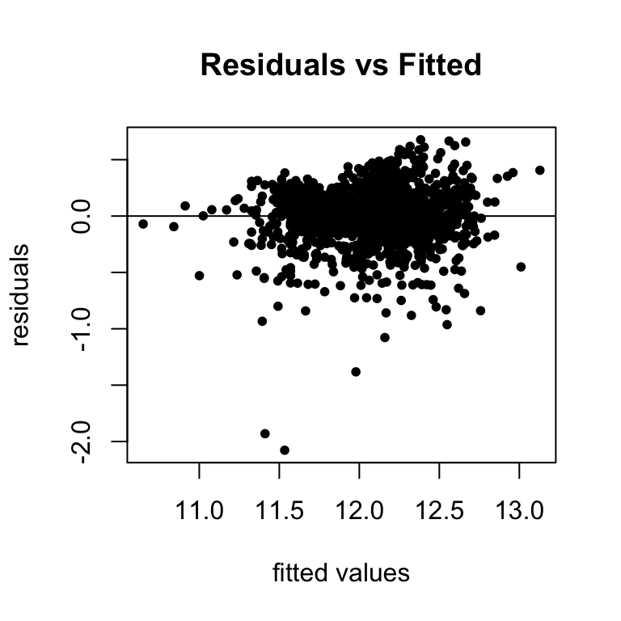

```
##
## Call:
## lm(formula = SalePriceLog ~ SqFtLog, data = houseData)
##
## Residuals:
##      Min       1Q   Median       3Q      Max
## -2.07739 -0.11664  0.01086  0.13813  0.67705
##
## Coefficients:
##             Estimate Std. Error t value Pr(>|t|)
## (Intercept)  5.01971    0.12666   39.63   <2e-16 ***
## SqFtLog      0.96880    0.01743   55.59   <2e-16 ***
## ---
## Signif. codes:  0 '***' 0.001 '**' 0.01 '*' 0.05 '.' 0.1 ' ' 1
##
## Residual standard error: 0.2366 on 1596 degrees of freedom
## Multiple R-squared:  0.6594, Adjusted R-squared:  0.6592
## F-statistic:  3090 on 1 and 1596 DF,  p-value: < 2.2e-16
```

# Assumptions

The assumptions for the linear regression modeling include:

- The Sale Price and Square Feet variables are independent of each other
- The distribution of Sale Prices are normal for each Square Foot value
- The variance is constant throughout all square feet values
- The mean function is ${E}(Y \mid X) = {\beta}_0 + {\beta}_1 X$

# Conclusion

Without conducting a log transfomation, the mean function for Sale Prices vs Square Feet is:

$Sale Price_i$ = 2066.4 + 122.2 x ($Square Feet_i$)

Interpreting the meaning of this model, for every square feet increase, the sale price increases by 122.2 dollars. The model shows that if the square footage was zero, the sale price would be $2066.4, however this doesnt make sense because no square footage is not worth anything, since there’s no area.

After the log transformation, the mean function becomes:

$Sale Price_i$ = 5.0197 + 0.9688 x ($Square Feet_i$)

By looking at the QQ plots for the original scatterplot, it doesn’t fit very well because at the beginning and the end, it curves away from the line. However, after completing a log transformation on the variables, the line fits much better than before.

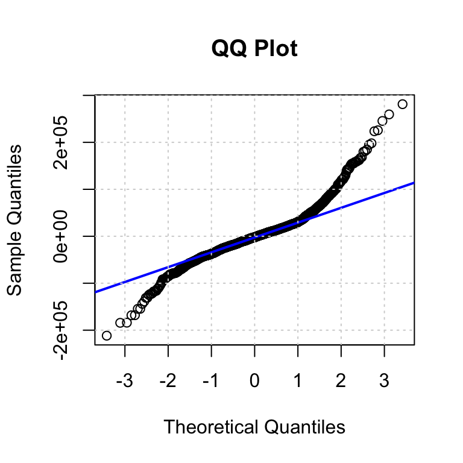

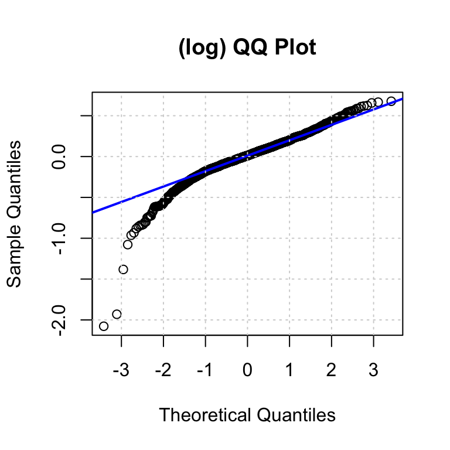

# Appendix

- SalePrice: The sale price of the residential property
- LotArea: Lot Size in square feet
- YearBuilt: Original construction date
- SqFt: Above grade living area square feet